# Freedom Case Study (Data Analytics)

Author - Prachir Agrawal

Date - 06/19/2021

====================================================

# This project is divided in 5 sections:

1. Introduction
1. Exploring The Data

   2.1 The Data
1. Exploratory Data Analysis (EDA)

   3.1 Describing Features

   3.2 Descriptive Figures

   3.2.1 Univariate Analysis

   3.2.2 Bivariate Analysis

   3.2.3 Multivariate Analysis

   3.2.4 Distribution Plots With Respect To Our Target Feature

   3.2.5 statistical significance p value Test
1. Actionable Recommendations
1. Extra - For the model building process.

   5.1 Feature Engineering

   5.1.1 Removing Some Features

   5.1.2 Processing Categorical Feature: One Hot-Encoding

   5.1.3 Heat Map and Pair Plot

# 1.Introduction

The Background: Freedom Debt Relief’s customers are people who have a substantial amount of debt and because of an unexpected hardship, are no longer able to make their minimum monthly payments. Upon enrolling in Freedom’s Debt Relief program, customers cease making payments to their creditors and instead make deposits they can afford into a new dedicated bank account with Freedom. Freedom uses these funds to negotiate with each of the client’s creditors to settle the debt, typically at only a fraction of what was originally owed. Once a settlement has been agreed upon for an individual account, Freedom facilitates payments from the dedicated bank account to the creditor based on the terms of the settlement agreement. Freedom then collects fees from the client for the individual account that was settled. Freedom earns fees for each account it successfully negotiates a settlement agreement. The number of settlement agreements Freedom can negotiate is proportional to the monthly deposited amount. Assume industry statistics for any analysis input that you would want to use that is not provided here, including but not limited to fee percentage Freedom would collect along with ongoing cost per client between initial enrollment and program graduation.

The Question: Imagine that Freedom ran a recent marketing campaign to promote the value proposition of how the debt relief program helps people achieve financial freedom. Assume the cost of this campaign was $5 million. There are five months of data in the datasets provided. Let’s say campaign took place over the course of the third month. You now want to show the marketing, sales and operations teams just how successful this campaign was. Using the three datasets given:

1. Provide a quantitative assessment of whether the marketing campaign was successful. How and why did you choose your specific success metric(s)?
2. Based on the provided data, how would you recommend campaign strategy be adjusted in the future to improve performance?
3. How to do you think campaign performance would have changed if we did not run the campaign in Month 3, but instead postponed it until month 6? Provide an incremental number versus your result in Question #1.
4. Is there anything not in the provided dataset that you think would provide value if added? If so, how would you strategize gathering and leveraging the additional information?

The Guardrails: You are free to use any tool or means you would like to highlight your abilities, but we would like to see something more advanced than Excel pivot tables, for example. We will be assessing not only on your ability to provide the correct results, but also how you decide to visualize and explain your results. Assume the following: • There is no seasonality in the results, and the campaign spend was distributed evenly across Month 3 (e.g., spend on the first day is the same as spend on the last day) • Channel mix, targeting, and efficiency are outside the scope of this exercise, but may be addressed as part of Question #4 • There may be data provided that is not useful in your end presentation Share your work back with us in this way:

1. Data Prep and Analysis: All methods, written code, visualizations and extrapolations, including any and all analysis that may or may not have made it into the final presentation; we are interested in your ability to see what is important for business stakeholders versus what is not.
2. Findings and Recommendations: Use a tool, like PowerPoint, to tell your story in a compelling way. Assume that your end result will be presented to a mixed audience of senior leadership, business stakeholders, and peers in business intelligence.

The Data: Attached you will find three files with the data you will need to complete the analysis.  
*Note: These datasets were created for this analytical exercise and are only intended to be used to assess the critical thinking and technical abilities of interview candidates. This data purposely does not reflect actual client or deposit information. No inferences should be made from this information in regard to Freedom’s client base, deposit activity, company size or company growth trajectory.

client_table: You will find data specific to fictional clients • client_id: Randomly generated unique surrogate identifier for a client • client_geographical_region: Client geographical location in relation to U.S. Census definitions • client_residence_status: Client residence status in relation to whether they rent or own • client_age: Client age in relation to date of birth

deposit_table: You will find data specific to the client deposit behavior • client_id: Randomly generated unique surrogate identifier for a client • deposit_type: Delineates whether a client deposit is the scheduled record or actual record • deposit_amount: Client deposit amount to the dedicated bank account with Freedom • deposit_cadence: Timing and pattern of client deposit activity • deposit_date: Deposit date for deposit type

calendar_table: This is a calendar reference table • gregorian_date: This date aligns with the Gregorian calendar • month_name: These are the designated months in the case study o Month 1 and 2 are pre-campaign o Month 3 is the campaign o Month 4 and 5 are post-campaign

```python
#Import the libraries
import pandas as pd
import numpy as np

from sklearn.linear_model import LogisticRegression

# importing ploting libraries
import matplotlib.pyplot as plt

# To enable plotting graphs in Jupyter notebook
%matplotlib inline

#importing seaborn for statistical plots
import seaborn as sns

#Let us break the X and y dataframes into training set and test set. For this we will use
#Sklearn package's data splitting function which is based on random function

from sklearn.model_selection import train_test_split

# calculate accuracy measures and confusion matrix
from sklearn import metrics

import warnings
warnings.filterwarnings('ignore')

import os,sys
from scipy import stats

import statistics

# calculate accuracy measures and confusion matrix
from sklearn import metrics

# Defining categorical, numerical, and datetime variables that we will use later
categorical_vars = ["client_geographical_region", "client_residence_status", "month_name","deposit_type","deposit_cadence"]
numerical_vars = ["client_id", "client_age", "deposit_amount"]
datetime_vars = ["gregorian_date","deposit_date"]
```

# 2. Exploring the Data

2.1 The data: There are three data sets provided with this problem.

```python
#Import the Dataset
df_client_data = pd.read_csv('candidate_case_study_client_data.csv')
df_calendar_data = pd.read_csv('candidate_case_study_calendar_data.csv')
df_deposit_date = pd.read_csv('candidate_case_study_deposit_data.csv')
```

```python
#Client Data Set records
df_client_data.head()
```

|  | client_id | client_geographical_region | client_residence_status | client_age |
| --- | --- | --- | --- | --- |
| 0 | 538839486596724 | Northeast | Rent | 91 |
| 1 | 321708286091707 | West | Own | 83 |
| 2 | 848531901757235 | Midwest | Own | 84 |
| 3 | 854405182328779 | Northeast | Own | 83 |
| 4 | 769102176031316 | West | Own | 85 |

```python
#Client Data Set records
df_calendar_data.head()
```

|  | gregorian_date | month_name |
| --- | --- | --- |
| 0 | 2019-06-01 | Month 1 |
| 1 | 2019-06-02 | Month 1 |
| 2 | 2019-06-03 | Month 1 |
| 3 | 2019-06-04 | Month 1 |
| 4 | 2019-06-05 | Month 1 |

```python
#Client Data Set records
df_deposit_date.head()
```

|  | client_id | deposit_type | deposit_amount | deposit_cadence | deposit_date |
| --- | --- | --- | --- | --- | --- |
| 0 | 446495122764671 | Actual Deposit | 303.0 | Monthly | 2019-10-23 |
| 1 | 446495122764671 | Actual Deposit | 303.0 | Monthly | 2019-09-23 |
| 2 | 446495122764671 | Scheduled Deposit | 303.0 | Monthly | 2019-09-23 |
| 3 | 446495122764671 | Scheduled Deposit | 303.0 | Monthly | 2019-10-23 |
| 4 | 446495122764671 | Scheduled Deposit | 303.0 | Monthly | 2019-06-23 |

Let's look at the main characteristics of our datasets, such as the number of observations, the type of variables, the summary statistics for each variables, the number of missing data, etc.

```python
#Shape - Number of Records in Data Sets:-
print("Shape of df_client_data: ", df_client_data.shape)
print("Shape of df_calendar_data: ", df_calendar_data.shape)
print("Shape of df_deposit_data: ", df_deposit_date.shape)
```

```
Shape of df_client_data:  (46347, 4)
Shape of df_calendar_data:  (153, 2)
Shape of df_deposit_data:  (480394, 5)
```

```python
#Info - Data Types and other details.
print(df_client_data.info())
print()
print(df_calendar_data.info())
print()
print(df_deposit_date.info())
print()
```

```
<class 'pandas.core.frame.DataFrame'>
RangeIndex: 46347 entries, 0 to 46346
Data columns (total 4 columns):
client_id                     46347 non-null int64
client_geographical_region    46347 non-null object
client_residence_status       46347 non-null object
client_age                    46347 non-null int64
dtypes: int64(2), object(2)
memory usage: 1.4+ MB
None

<class 'pandas.core.frame.DataFrame'>
RangeIndex: 153 entries, 0 to 152
Data columns (total 2 columns):
gregorian_date    153 non-null object
month_name        153 non-null object
dtypes: object(2)
memory usage: 2.5+ KB
None

<class 'pandas.core.frame.DataFrame'>
RangeIndex: 480394 entries, 0 to 480393
Data columns (total 5 columns):
client_id          480394 non-null int64
deposit_type       480394 non-null object
deposit_amount     480394 non-null float64
deposit_cadence    480394 non-null object
deposit_date       480394 non-null object
dtypes: float64(1), int64(1), object(3)
memory usage: 18.3+ MB
None
```

```python
#null values or incorrect imputation - From below data looks clean and no 'NA' values.
print(df_client_data.isnull().sum())
print()
print(df_calendar_data.isnull().sum())
print()
print(df_deposit_date.isnull().sum())
print()
print(df_client_data.isna().sum())
print()
print(df_calendar_data.isna().sum())
print()
print(df_deposit_date.isna().sum())
```

```
client_id                     0
client_geographical_region    0
client_residence_status       0
client_age                    0
dtype: int64

gregorian_date    0
month_name        0
dtype: int64

client_id          0
deposit_type       0
deposit_amount     0
deposit_cadence    0
deposit_date       0
dtype: int64

client_id                     0
client_geographical_region    0
client_residence_status       0
client_age                    0
dtype: int64

gregorian_date    0
month_name        0
dtype: int64

client_id          0
deposit_type       0
deposit_amount     0
deposit_cadence    0
deposit_date       0
dtype: int64
```

```python
# Duplicate Record Check - Assessing if duplicated records are found in the dataset
print("Number of duplicated records in df_client_data: ", df_client_data.duplicated().sum())
print("Number of duplicated records in df_calendar_data: ", df_calendar_data.duplicated().sum())
print("Number of duplicated records in df_deposit_data: ", df_deposit_date.duplicated().sum())
```

```
Number of duplicated records in df_client_data:  0
Number of duplicated records in df_calendar_data:  0
Number of duplicated records in df_deposit_data:  8375
```

```python
# Removing the duplicated rows from the dataset
df_deposit_date = df_deposit_date.drop_duplicates()
```

```python
#Validating for Duplicate after removing it.
print("Number of duplicated records in df_deposit_data: ", df_deposit_date.duplicated().sum())
print("New Shape after removing duplicate records : ", df_deposit_date.shape)
```

```
Number of duplicated records in df_deposit_data:  0
New Shape after removing duplicate records :  (472019, 5)
```

```python
# Merge the Data Sets - client_deposit and deposit_date data frames:-
df_client_deposit = pd.merge(df_deposit_date, df_client_data, on='client_id')
```

```python
#Checking number of records for the validation purpose.
df_client_deposit.shape
```

```
(472019, 8)
```

```python
#Merged Data Set View:-
df_client_deposit.head()
```

|  | client_id | deposit_type | deposit_amount | deposit_cadence | deposit_date | client_geographical_region | client_residence_status | client_age |
| --- | --- | --- | --- | --- | --- | --- | --- | --- |
| 0 | 446495122764671 | Actual Deposit | 303.0 | Monthly | 2019-10-23 | West | Rent | 53 |
| 1 | 446495122764671 | Actual Deposit | 303.0 | Monthly | 2019-09-23 | West | Rent | 53 |
| 2 | 446495122764671 | Scheduled Deposit | 303.0 | Monthly | 2019-09-23 | West | Rent | 53 |
| 3 | 446495122764671 | Scheduled Deposit | 303.0 | Monthly | 2019-10-23 | West | Rent | 53 |
| 4 | 446495122764671 | Scheduled Deposit | 303.0 | Monthly | 2019-06-23 | West | Rent | 53 |

```python
# Join the Data Sets with the calendar data
df_freedom = df_client_deposit.join(df_calendar_data.set_index('gregorian_date'), on='deposit_date')
print("New Shape after Joining all the data sets : ", df_freedom.shape)
```

```
New Shape after Joining all the data sets :  (472019, 9)
```

```python
print("New Shape after Join all the data sets : ", df_freedom.shape)
df_freedom.head()
```

```
New Shape after Join all the data sets :  (472019, 9)
```

|  | client_id | deposit_type | deposit_amount | deposit_cadence | deposit_date | client_geographical_region | client_residence_status | client_age | month_name |
| --- | --- | --- | --- | --- | --- | --- | --- | --- | --- |
| 0 | 446495122764671 | Actual Deposit | 303.0 | Monthly | 2019-10-23 | West | Rent | 53 | Month 5 |
| 1 | 446495122764671 | Actual Deposit | 303.0 | Monthly | 2019-09-23 | West | Rent | 53 | Month 4 |
| 2 | 446495122764671 | Scheduled Deposit | 303.0 | Monthly | 2019-09-23 | West | Rent | 53 | Month 4 |
| 3 | 446495122764671 | Scheduled Deposit | 303.0 | Monthly | 2019-10-23 | West | Rent | 53 | Month 5 |
| 4 | 446495122764671 | Scheduled Deposit | 303.0 | Monthly | 2019-06-23 | West | Rent | 53 | Month 1 |

```python
# Duplicate Record Check - After Merging the data sets.
print("Number of duplicated records in df_client_data: ", df_freedom.duplicated().sum())
```

```
Number of duplicated records in df_client_data:  0
```

Now our data is ready for the exploratory data analysis and in the next section we will get more insight about our data.

# 3. Exploratory Data Analysis (EDA)

```
    3.1 Describing The Features
```

```python
# Extract Descriptive Statistics
df_freedom.describe()
```

|  | client_id | deposit_amount | client_age |
| --- | --- | --- | --- |
| count | 4.720190e+05 | 472019.000000 | 472019.000000 |
| mean | 4.994570e+14 | 365.188969 | 52.209142 |
| std | 2.899547e+14 | 347.745421 | 13.767452 |
| min | 1.460463e+11 | 0.010000 | 21.000000 |
| 25% | 2.480999e+14 | 200.000000 | 41.000000 |
| 50% | 5.017881e+14 | 290.000000 | 52.000000 |
| 75% | 7.505442e+14 | 453.000000 | 62.000000 |
| max | 9.999856e+14 | 30000.000000 | 105.000000 |

From abouve statistics observed below points:-

1. Min and MAx values for deposit_amount and client_age are in valid range.
2. we can ignore the client id as its continous number for the ID creation. (Keeping Client ID for further analysis)
3. For Client_age column we have almost same Mean and Median valuses that represents the normal distribution and will observe that same when will plot on client_age column.
4. Deposit Amount can be vary and few customers may have greater deposit amount resulted differences in mean and median values.

# 3.2 Descriptive Figures

Univariate Analysis

```python
# Functions that we will use later on for the plots
def data_info(data):
    return data.info()

def creating_boxplots(size, features, data):
    plt.figure(figsize=size)
    for i in range(len(numerical_vars)):
        plt.subplot(5, 2, i+1)
        sns.boxplot(x=features[i], data=data)

def creating_distplot(size, data, features):
    plt.figure(figsize=size)
    for i in range(len(features)):
        plt.subplot(5, 3, i+1)
        sns.distplot(data[features[i]])

def creating_countplot(size, features, data):
    plt.figure(figsize=size)
    for i in range(len(features)):
        plt.subplot(5, 3, i+1)
        sns.countplot(x=features[i], data=data )

def crossCorrelation(data):
    corr = data.corr()
    plt.figure(figsize=(10,6))
    sns.heatmap(corr,
          xticklabels=corr.columns.values,
          yticklabels=corr.columns.values)
    print(corr)

num_vars = df_freedom.select_dtypes(exclude=['object', 'datetime64']).columns
cat_vars = df_freedom.select_dtypes(exclude=['int64', 'float64']).columns
```

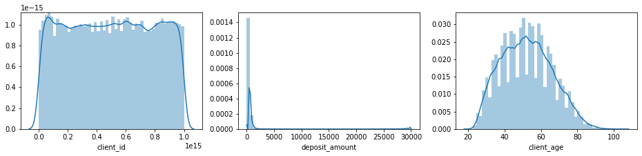

```python
# # Generating distribution plots with respect to our number of transactions feature
creating_distplot((16,18), df_freedom, num_vars)
```

As we observed during Descriptive Statistics, we can have similar observations for deposit_amount and client_age features.

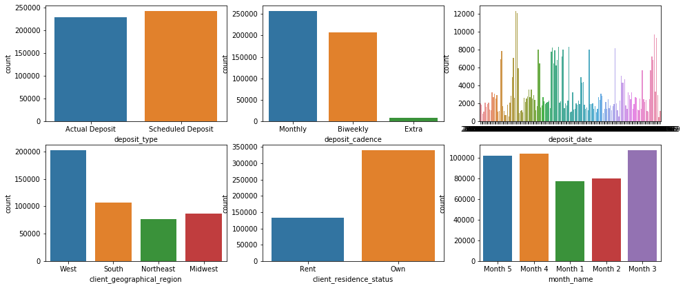

```python
# Generating countplots with respect to our number of transactions
creating_countplot((16,18), cat_vars, df_freedom)
```

From above count plots we have below observations:-

1. Scheduled deposits counts are more than Actual Deposit.
2. Deposit Cadence - There are few Extra payments and monthly transactions are more as compared to Bi-Weekly.
3. West Region have more transactions as compared to other regions
4. Customers who owns residence having more transacrions.
5. Month - 3 which is a campaign month having more number of transactions as compared to pre-campaign months 1 and 2.

# 3.2.2 Bivariate Analysis

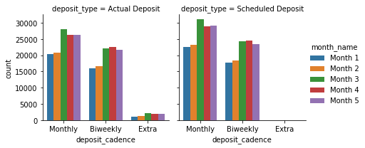

```python
sns.catplot(x="deposit_cadence", hue ="month_name",hue_order = np.sort(df_freedom['month_name'].unique()),col="deposit_type",
                data=df_freedom, kind="count",
                height=3, aspect=1);
```

By Deposit Cadence and we can see all Extra deposits under Actual deposit type which make sense.

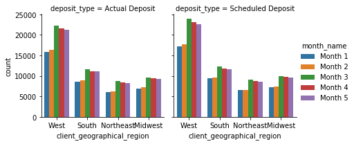

```python
sns.catplot(x="client_geographical_region", hue ="month_name",hue_order = np.sort(df_freedom['month_name'].unique()),col="deposit_type",
                data=df_freedom, kind="count",
                height=3, aspect=1);
```

Geographical Region wise analysis for all 5 months and we can see west region is having lot of traffic and high bar for month 3 and after.

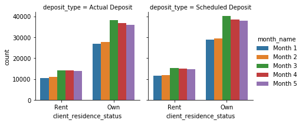

```python
sns.catplot(x="client_residence_status", hue ="month_name",hue_order = np.sort(df_freedom['month_name'].unique()),col="deposit_type",
                data=df_freedom, kind="count",
                height=3, aspect=1);
```

Client Residence Staus - More customer who owns residence.

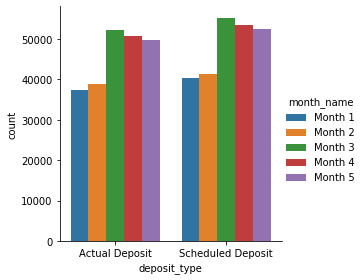

```python
sns.catplot(x="deposit_type", hue ="month_name",hue_order = np.sort(df_freedom['month_name'].unique()),
                data=df_freedom, kind="count",
                height=4, aspect=1);
```

# 3.2.3 Multivariate Analysis:

```python
#Removing client_id and Deposit deposit_date as it will be 1-1 mapping.

df_freedom = df_freedom.drop('client_id', axis =1 ) # dropping this column as it will be 1-1 mapping.
df_freedom = df_freedom.drop('deposit_date', axis =1 ) # dropping this column as it will be 1-1 mapping.
```

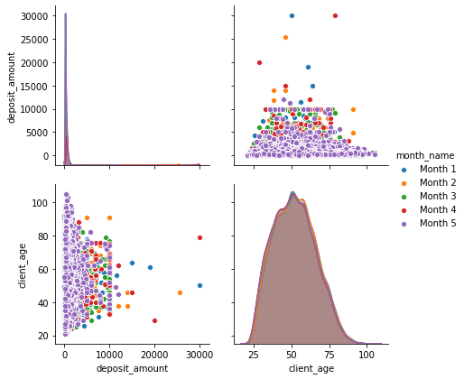

```python
#pairplot
sns.pairplot(df_freedom, hue="month_name", hue_order = np.sort(df_freedom['month_name'].unique()),size = 3)
plt.show()
```

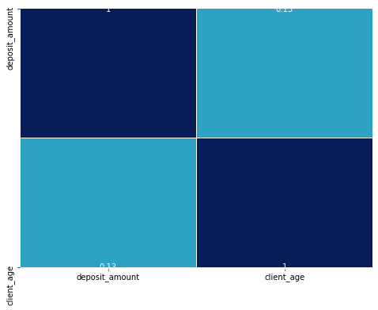

```python
plt.figure(figsize=(8,6))
sns.heatmap(df_freedom.corr(),
            annot=True,
            linewidths=.5,
            center=0,
            cbar=False,
            cmap="YlGnBu")
plt.show()
```

No high Co-relation between deposit amount and Age.

# 3.2.4 Plots With Respect To Deposit Amount

```python
#Split 1 - Based on the Actual Deposits and Scheduled Deposit
grouped = df_freedom.groupby(df_freedom.deposit_type)
df_actual_deposit = grouped.get_group("Actual Deposit")
df_actual_deposit.head()
df_actual_deposit.shape
```

```
(229014, 7)
```

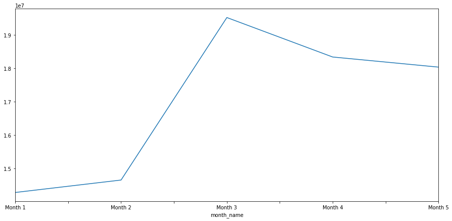

```python
# plot data
fig, ax = plt.subplots(figsize=(15,7))
# use unstack()
df_actual_deposit.groupby(['month_name']).sum()['deposit_amount'].plot(ax=ax)
```

As we can observe from above chart that Month 3 (campaign month) is having highest actual deposit SUM.

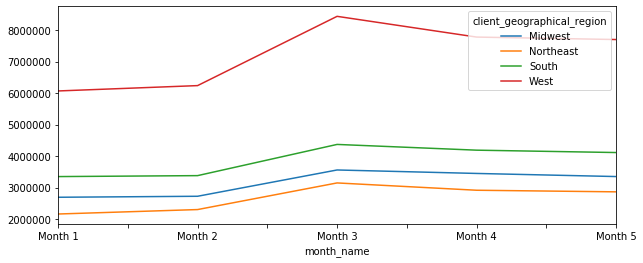

```python
# Plot As per Geographical Region
fig, ax = plt.subplots(figsize=(10,4))
# use unstack()
df_actual_deposit.groupby(['month_name','client_geographical_region']).sum()['deposit_amount'].unstack().plot(ax=ax)
```

As we can observe region wise performace.

```python
# adding a column Age Group for the distribution:-
df_actual_deposit['Age_Group'] = df_actual_deposit.apply(lambda row: round(row.client_age / 10) * 10 , axis = 1)
```

```python
#View with Age Group Column
df_actual_deposit.head()
```

|  | deposit_type | deposit_amount | deposit_cadence | client_geographical_region | client_residence_status | client_age | month_name | Age_Group |
| --- | --- | --- | --- | --- | --- | --- | --- | --- |
| 0 | Actual Deposit | 303.0 | Monthly | West | Rent | 53 | Month 5 | 50 |
| 1 | Actual Deposit | 303.0 | Monthly | West | Rent | 53 | Month 4 | 50 |
| 6 | Actual Deposit | 303.0 | Monthly | West | Rent | 53 | Month 1 | 50 |
| 7 | Actual Deposit | 303.0 | Monthly | West | Rent | 53 | Month 2 | 50 |
| 9 | Actual Deposit | 303.0 | Monthly | West | Rent | 53 | Month 3 | 50 |

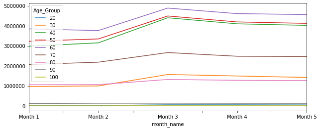

```python
# Plot As per Age Groups
fig, ax = plt.subplots(figsize=(10,4))
# use unstack()
df_actual_deposit.groupby(['month_name','Age_Group']).sum()['deposit_amount'].unstack().plot(ax=ax)
```

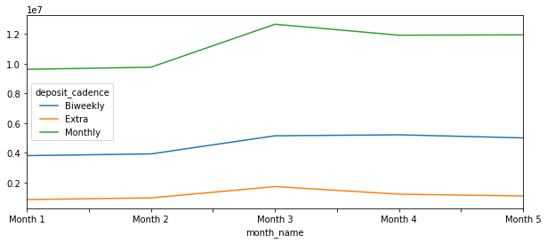

```python
# Based on the Deposit Candence.
fig, ax = plt.subplots(figsize=(10,4))
# use unstack()
df_actual_deposit.groupby(['month_name','deposit_cadence']).sum()['deposit_amount'].unstack().plot(ax=ax)
```

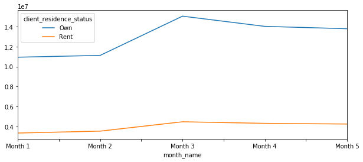

```python
# Based on the Residence Status.
fig, ax = plt.subplots(figsize=(10,4))
# use unstack()
df_actual_deposit.groupby(['month_name','client_residence_status']).sum()['deposit_amount'].unstack().plot(ax=ax)
```

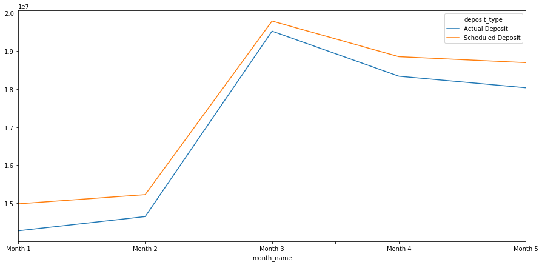

```python
# Based on the Deposit Type:-
fig, ax = plt.subplots(figsize=(15,7))
# use unstack()
df_freedom.groupby(['month_name','deposit_type']).sum()['deposit_amount'].unstack().plot(ax=ax)
```

```python
#Split 2 - Based on the Actual Deposits and Scheduled Deposit
# Month 1 and 2 are pre-campaign
# Month 3 is the campaign
# Month 4 and 5 are post-campaign

grouped1 = df_actual_deposit.groupby(df_freedom.month_name)
df_month_1 = grouped1.get_group("Month 1")
df_month_2 = grouped1.get_group("Month 2")
df_month_3 = grouped1.get_group("Month 3")
df_month_4 = grouped1.get_group("Month 4")
df_month_5 = grouped1.get_group("Month 5")
```

```python
#Counts - To get the number of Transactions for each months.
print("Trancation counts of Actual Deposit of Month 1: ",df_month_1['deposit_amount'].count())
print("Trancation counts of Actual Deposit of Month 2: ",df_month_2['deposit_amount'].count())
print("Trancation counts of Actual Deposit of Month 3: ",df_month_3['deposit_amount'].count())
print("Trancation counts of Actual Deposit of Month 4: ",df_month_4['deposit_amount'].count())
print("Trancation counts of Actual Deposit of Month 5: ",df_month_5['deposit_amount'].count())
```

```
Trancation counts of Actual Deposit of Month 1:  37448
Trancation counts of Actual Deposit of Month 2:  38770
Trancation counts of Actual Deposit of Month 3:  52216
Trancation counts of Actual Deposit of Month 4:  50799
Trancation counts of Actual Deposit of Month 5:  49781
```

```python
#Actual Deposit Amount Sums based on the Months.
print("Sum of Actual Deposit of Month 1: ",df_month_1['deposit_amount'].sum())
print("Sum of Actual Deposit of Month 2: ",df_month_2['deposit_amount'].sum())
print("Sum of Actual Deposit of Month 3: ",df_month_3['deposit_amount'].sum())
print("Sum of Actual Deposit of Month 4: ",df_month_4['deposit_amount'].sum())
print("Sum of Actual Deposit of Month 5: ",df_month_5['deposit_amount'].sum())
```

```
Sum of Actual Deposit of Month 1:  14278180.25
Sum of Actual Deposit of Month 2:  14651086.58
Sum of Actual Deposit of Month 3:  19522177.049999997
Sum of Actual Deposit of Month 4:  18339240.18
Sum of Actual Deposit of Month 5:  18036150.8
```